# p8105_hw5

Tom Carpino, tc2899

November 8, 2018

This homework flexes our skills on iteration and graphing.

### Problem 1: Case Control Study

- The format of this problem involves the following:
  - Importing the dataset
  - Tidying the dataset and creating a usable dataframe
  - Creating a spaghetti plot
- I loaded the following packages, using the suppressMessages function:
  - tidyverse
  - plotly
  - rvest
  - magrittr

Listing Files

```r
listed_files = tibble(filepath = list.files("./data/", pattern = "*.csv", full.names = TRUE),
                         filename = basename(filepath))
```

Writing a function to read the data:

```r
read_fx = function(data){
  read_csv(file = data)
}
```

Creating the dataframe using a `map` function:

```r
df_patient =
  listed_files %>%
  mutate(data =  purrr::map(listed_files$filepath, read_fx)) %>%
  unnest() %>%
  select(-filepath) %>%
  gather(key = week, value = value, week_1:week_8) %>%
  mutate(
    id = str_replace(filename, ".csv",""),
    week = as.numeric(str_replace(week, "week_", ""))) %>%
  separate(id, into = c("group", "id"), sep = "_") %>%
  mutate(id = as.factor(id))

df_patient
```

```
## # A tibble: 160 x 5
##    filename    week value group id
##    <chr>      <dbl> <dbl> <chr> <fct>
##  1 con_01.csv     1  0.2  con   01
##  2 con_02.csv     1  1.13 con   02
##  3 con_03.csv     1  1.77 con   03
##  4 con_04.csv     1  1.04 con   04
##  5 con_05.csv     1  0.47 con   05
##  6 con_06.csv     1  2.37 con   06
##  7 con_07.csv     1  0.03 con   07
##  8 con_08.csv     1 -0.08 con   08
##  9 con_09.csv     1  0.08 con   09
## 10 con_10.csv     1  2.14 con   10
## # ... with 150 more rows
```

Creating the Spaghetti Plot:

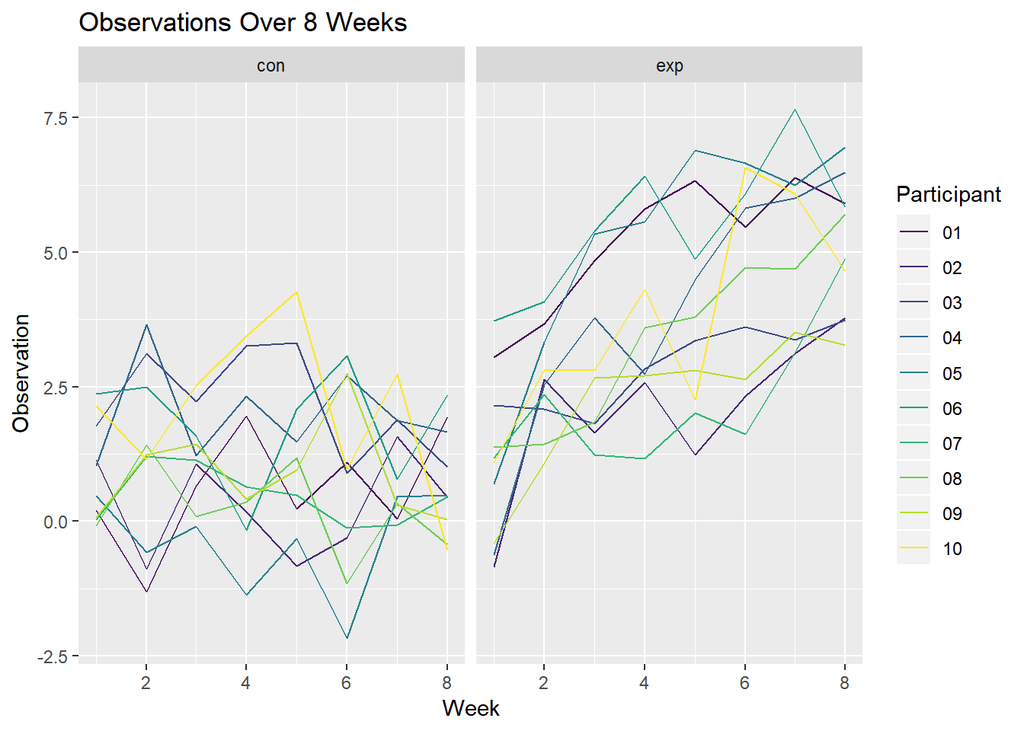

```r
ggplot(
  df_patient,
  aes(x = week, y = value, color = id, group = id)) +
  geom_line() +
  facet_grid(~group) +
  labs(
    title = "Observations Over 8 Weeks",
    x = "Week",
    y = "Observation",
    color = "Participant") +
    viridis::scale_color_viridis(discrete = TRUE)
```

### Problem 2: Homicide in Large Cities

- The format of this problem involves the following:
  - Using the existing repo
  - Describing data
  - Using functions to estimate crime rates
  - Creating plots with CIs

```r
homicide =
  read_csv("https://raw.githubusercontent.com/washingtonpost/data-homicides/master/homicide-data.csv", col_names = TRUE) %>%
  mutate(city_state = str_c(city, ",", " ", state))
```

#### Description

The dataset pulled from the *Washington Post* has **52179** observations across **13** variables that include information about the location (latitude and longitude) of the homicide and the victim (first and last name, age, sex, race).

#### Estimating Homicide Rates in Baltimore

Here I am summarizing within the cities the disposition variable (closed or open cases with no arrests):

```r
sum_cities = homicide %>%
  mutate(disposition = fct_collapse(homicide$disposition, "No arrest" = c("Closed without arrest","Open/No arrest"))) %>% group_by(city_state) %>%
  count(disposition) %>%
  spread(key = disposition, value = n) %>%
  janitor::clean_names() %>%
  mutate(total = closed_by_arrest + no_arrest)
```

Here I am using the prop.test function to estimate the propportion of homicides that are unsolved in Baltimore using the *sum_cities* dataframe I just created.

```r
bmore = sum_cities %>% filter(city_state == "Baltimore, MD")
bmore_disp = prop.test(bmore$no_arrest, bmore$total) %>%
  broom::tidy() %>%
  select(estimate, conf.low, conf.high) %>%
  janitor::clean_names() %>%
  knitr::kable()
bmore_disp
```

| estimate | conf_low | conf_high |
| --- | --- | --- |
| 0.6455607 | 0.6275625 | 0.6631599 |

This finds that approximately 64.55% of all of the cases of homicides in Baltimore do not have any arrests, with the lower estimate being 62.75% and the upper estimate being 66.31%. This is scary.

### Creating Plots

Prop Test Function:

```r
prop_test = function(data_table){

  try(prop.test(data_table$no_arrest, data_table$total) %>%
    broom::tidy() %>%
    select(estimate, conf.low, conf.high), silent = TRUE)
}
```

Using iteration methods:

```r
ci_states = sum_cities %>% group_by(city_state) %>% nest() %>%
  mutate(estimate_ci = map(data, prop_test)) %>% filter(city_state != "Tulsa, AL") %>% unnest() %>%
  mutate(city_state = reorder(city_state, estimate)) %>% janitor::clean_names()
```

Creating the actual plot using ggplot:

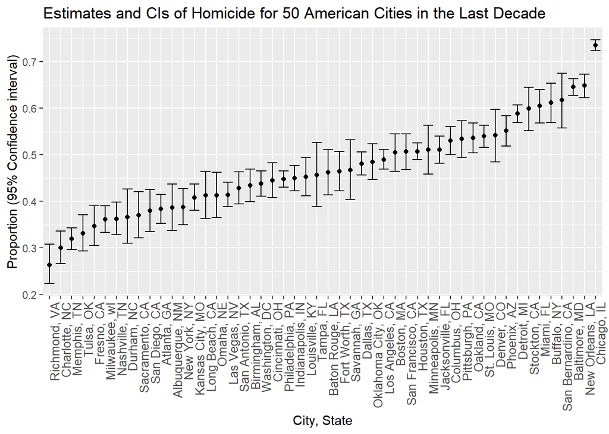

```r
ggplot(ci_states, aes(x = city_state, y = estimate )) +
  geom_point() + geom_errorbar(aes(ymin = conf_low, ymax = conf_high)) +
  theme(axis.text.x = element_text(angle = 90, hjust = 1, size = 10)) +
  labs(
    x = "City, State",
    y = "Proportion (95% Confidence interval)",
    title = "Estimates and CIs of Homicide for 50 American Cities in the Last Decade"
  )
```